# Project 2: TMDB-MOVIES Dataset Investigation

- Introduction
- Data Wrangling
- Exploratory Data Analysis
- Conclusions
- References

## *Introduction*

### This dataset contains information about a lot of movies produced and released in a period of years ( from 1960 to 2015 ) along with some attributes to each movie like the actors , the genre , the budget , the producing companies , the revenue , the vote average ...etc.

### In this dataset , we want to investigate its properties and try to derive some relationships between its attributes.

### Mainly this investigation aims to answer the following questions :

```python
#Here we are firstly importing the python libraries which we are going to use in this investigation
import numpy as ny
import pandas as pa
import matplotlib.pyplot as plt
import seaborn as sn


#magic command to render the graphs inline with our code in Jupyter notebook
%matplotlib inline
```

## *Data Wrangling*

#### We are going to open the dataset and try to five through its data to see how it can be cleaned to be ready for investigation .

```python
#load the csv file
df=pa.read_csv("tmdb-movies.csv")
```

```python
#show the first five row of the dataset to get a look at the data
df.head()
```

|  | id | imdb_id | popularity | budget | revenue | original_title | cast | homepage | director | tagline | ... | overview | runtime | genres | production_companies | release_date | vote_count | vote_average | release_year | budget_adj | revenue_adj |
| --- | --- | --- | --- | --- | --- | --- | --- | --- | --- | --- | --- | --- | --- | --- | --- | --- | --- | --- | --- | --- | --- |
| 0 | 135397 | tt0369610 | 32.985763 | 150000000 | 1513528810 | Jurassic World | Chris Pratt\|Bryce Dallas Howard\|Irrfan Khan\|Vi... | http://www.jurassicworld.com/ | Colin Trevorrow | The park is open. | ... | Twenty-two years after the events of Jurassic ... | 124 | Action\|Adventure\|Science Fiction\|Thriller | Universal Studios\|Amblin Entertainment\|Legenda... | 6/9/15 | 5562 | 6.5 | 2015 | 1.379999e+08 | 1.392446e+09 |
| 1 | 76341 | tt1392190 | 28.419936 | 150000000 | 378436354 | Mad Max: Fury Road | Tom Hardy\|Charlize Theron\|Hugh Keays-Byrne\|Nic... | http://www.madmaxmovie.com/ | George Miller | What a Lovely Day. | ... | An apocalyptic story set in the furthest reach... | 120 | Action\|Adventure\|Science Fiction\|Thriller | Village Roadshow Pictures\|Kennedy Miller Produ... | 5/13/15 | 6185 | 7.1 | 2015 | 1.379999e+08 | 3.481613e+08 |
| 2 | 262500 | tt2908446 | 13.112507 | 110000000 | 295238201 | Insurgent | Shailene Woodley\|Theo James\|Kate Winslet\|Ansel... | http://www.thedivergentseries.movie/#insurgent | Robert Schwentke | One Choice Can Destroy You | ... | Beatrice Prior must confront her inner demons ... | 119 | Adventure\|Science Fiction\|Thriller | Summit Entertainment\|Mandeville Films\|Red Wago... | 3/18/15 | 2480 | 6.3 | 2015 | 1.012000e+08 | 2.716190e+08 |
| 3 | 140607 | tt2488496 | 11.173104 | 200000000 | 2068178225 | Star Wars: The Force Awakens | Harrison Ford\|Mark Hamill\|Carrie Fisher\|Adam D... | http://www.starwars.com/films/star-wars-episod... | J.J. Abrams | Every generation has a story. | ... | Thirty years after defeating the Galactic Empi... | 136 | Action\|Adventure\|Science Fiction\|Fantasy | Lucasfilm\|Truenorth Productions\|Bad Robot | 12/15/15 | 5292 | 7.5 | 2015 | 1.839999e+08 | 1.902723e+09 |
| 4 | 168259 | tt2820852 | 9.335014 | 190000000 | 1506249360 | Furious 7 | Vin Diesel\|Paul Walker\|Jason Statham\|Michelle ... | http://www.furious7.com/ | James Wan | Vengeance Hits Home | ... | Deckard Shaw seeks revenge against Dominic Tor... | 137 | Action\|Crime\|Thriller | Universal Pictures\|Original Film\|Media Rights ... | 4/1/15 | 2947 | 7.3 | 2015 | 1.747999e+08 | 1.385749e+09 |

5 rows × 21 columns

It seems that the dataset contains 21 columns , and of course we will not use them all , so we will delete some of the irrelevant columns to our analysis to keep only the relevant information .

Also there are some columns which have multi values seperated by | .

```python
#we want to know some info about the rows and the columns of the dataset
df.info()
```

```
<class 'pandas.core.frame.DataFrame'>
RangeIndex: 10866 entries, 0 to 10865
Data columns (total 21 columns):
 #   Column                Non-Null Count  Dtype
---  ------                --------------  -----
 0   id                    10866 non-null  int64
 1   imdb_id               10856 non-null  object
 2   popularity            10866 non-null  float64
 3   budget                10866 non-null  int64
 4   revenue               10866 non-null  int64
 5   original_title        10866 non-null  object
 6   cast                  10790 non-null  object
 7   homepage              2936 non-null   object
 8   director              10822 non-null  object
 9   tagline               8042 non-null   object
 10  keywords              9373 non-null   object
 11  overview              10862 non-null  object
 12  runtime               10866 non-null  int64
 13  genres                10843 non-null  object
 14  production_companies  9836 non-null   object
 15  release_date          10866 non-null  object
 16  vote_count            10866 non-null  int64
 17  vote_average          10866 non-null  float64
 18  release_year          10866 non-null  int64
 19  budget_adj            10866 non-null  float64
 20  revenue_adj           10866 non-null  float64
dtypes: float64(4), int64(6), object(11)
memory usage: 1.7+ MB
```

```python
#showing some statistical calculations of the dataset
df.describe()
```

|  | id | popularity | budget | revenue | runtime | vote_count | vote_average | release_year | budget_adj | revenue_adj |
| --- | --- | --- | --- | --- | --- | --- | --- | --- | --- | --- |
| count | 10866.000000 | 10866.000000 | 1.086600e+04 | 1.086600e+04 | 10866.000000 | 10866.000000 | 10866.000000 | 10866.000000 | 1.086600e+04 | 1.086600e+04 |
| mean | 66064.177434 | 0.646441 | 1.462570e+07 | 3.982332e+07 | 102.070863 | 217.389748 | 5.974922 | 2001.322658 | 1.755104e+07 | 5.136436e+07 |
| std | 92130.136561 | 1.000185 | 3.091321e+07 | 1.170035e+08 | 31.381405 | 575.619058 | 0.935142 | 12.812941 | 3.430616e+07 | 1.446325e+08 |
| min | 5.000000 | 0.000065 | 0.000000e+00 | 0.000000e+00 | 0.000000 | 10.000000 | 1.500000 | 1960.000000 | 0.000000e+00 | 0.000000e+00 |
| 25% | 10596.250000 | 0.207583 | 0.000000e+00 | 0.000000e+00 | 90.000000 | 17.000000 | 5.400000 | 1995.000000 | 0.000000e+00 | 0.000000e+00 |
| 50% | 20669.000000 | 0.383856 | 0.000000e+00 | 0.000000e+00 | 99.000000 | 38.000000 | 6.000000 | 2006.000000 | 0.000000e+00 | 0.000000e+00 |
| 75% | 75610.000000 | 0.713817 | 1.500000e+07 | 2.400000e+07 | 111.000000 | 145.750000 | 6.600000 | 2011.000000 | 2.085325e+07 | 3.369710e+07 |
| max | 417859.000000 | 32.985763 | 4.250000e+08 | 2.781506e+09 | 900.000000 | 9767.000000 | 9.200000 | 2015.000000 | 4.250000e+08 | 2.827124e+09 |

From the describe function , we notice that more than half ofthe data in the columns budget and revenue are zero values , which indicates that all these data is unknown , so with dealing with such data will produce biased results .

```python
#check for duplicated rows in the dataset
df.duplicated()
```

```
0        False
1        False
2        False
3        False
4        False
         ...
10861    False
10862    False
10863    False
10864    False
10865    False
Length: 10866, dtype: bool
```

## *Data Cleaning*

As we had an overview of the dataset in the last section , let's go on with some data cleaning , so that the dataset is ready to be analysed .

## step 1

we will drop the duplicate rows in the dataset (if any)

```python
df=df.drop_duplicates()
```

## step 2

ًWe need to drop the useless columns . The columns we don't need are ( id, imdb_id, popularity, homepage, tagline ,overview ).

Note that we will delete also the columns "budget" , "revenue" , "budget_adj" , "revenue_adj" as they are not very useful information as more than half of the dataset in these columns are unknown values.

```python
#we use drop function to delete the mentioned columns
df=df.drop(['id', 'imdb_id','popularity','budget','revenue', 'homepage','overview', 'tagline', 'budget_adj','revenue_adj'], axis = 1)
df.head()
```

|  | original_title | cast | director | keywords | runtime | genres | production_companies | release_date | vote_count | vote_average | release_year |
| --- | --- | --- | --- | --- | --- | --- | --- | --- | --- | --- | --- |
| 0 | Jurassic World | Chris Pratt\|Bryce Dallas Howard\|Irrfan Khan\|Vi... | Colin Trevorrow | monster\|dna\|tyrannosaurus rex\|velociraptor\|island | 124 | Action\|Adventure\|Science Fiction\|Thriller | Universal Studios\|Amblin Entertainment\|Legenda... | 6/9/15 | 5562 | 6.5 | 2015 |
| 1 | Mad Max: Fury Road | Tom Hardy\|Charlize Theron\|Hugh Keays-Byrne\|Nic... | George Miller | future\|chase\|post-apocalyptic\|dystopia\|australia | 120 | Action\|Adventure\|Science Fiction\|Thriller | Village Roadshow Pictures\|Kennedy Miller Produ... | 5/13/15 | 6185 | 7.1 | 2015 |
| 2 | Insurgent | Shailene Woodley\|Theo James\|Kate Winslet\|Ansel... | Robert Schwentke | based on novel\|revolution\|dystopia\|sequel\|dyst... | 119 | Adventure\|Science Fiction\|Thriller | Summit Entertainment\|Mandeville Films\|Red Wago... | 3/18/15 | 2480 | 6.3 | 2015 |
| 3 | Star Wars: The Force Awakens | Harrison Ford\|Mark Hamill\|Carrie Fisher\|Adam D... | J.J. Abrams | android\|spaceship\|jedi\|space opera\|3d | 136 | Action\|Adventure\|Science Fiction\|Fantasy | Lucasfilm\|Truenorth Productions\|Bad Robot | 12/15/15 | 5292 | 7.5 | 2015 |
| 4 | Furious 7 | Vin Diesel\|Paul Walker\|Jason Statham\|Michelle ... | James Wan | car race\|speed\|revenge\|suspense\|car | 137 | Action\|Crime\|Thriller | Universal Pictures\|Original Film\|Media Rights ... | 4/1/15 | 2947 | 7.3 | 2015 |

## step 3

We will convert the release_date to date time type instead of string .

```python
#we will use 'to date time' function
df['release_date']= pa.to_datetime(df['release_date'])
```

```python
#check that conversion is done successfully
df.dtypes
```

```
original_title                  object
cast                            object
director                        object
keywords                        object
runtime                          int64
genres                          object
production_companies            object
release_date            datetime64[ns]
vote_count                       int64
vote_average                   float64
release_year                     int64
dtype: object
```

## step 4

Here we will drop any row with null values so that we can process our valid data only .

```python
#we use dropna function
df=df.dropna()
```

```python
df.head()
```

|  | original_title | cast | director | keywords | runtime | genres | production_companies | release_date | vote_count | vote_average | release_year |
| --- | --- | --- | --- | --- | --- | --- | --- | --- | --- | --- | --- |
| 0 | Jurassic World | Chris Pratt\|Bryce Dallas Howard\|Irrfan Khan\|Vi... | Colin Trevorrow | monster\|dna\|tyrannosaurus rex\|velociraptor\|island | 124 | Action\|Adventure\|Science Fiction\|Thriller | Universal Studios\|Amblin Entertainment\|Legenda... | 2015-06-09 | 5562 | 6.5 | 2015 |
| 1 | Mad Max: Fury Road | Tom Hardy\|Charlize Theron\|Hugh Keays-Byrne\|Nic... | George Miller | future\|chase\|post-apocalyptic\|dystopia\|australia | 120 | Action\|Adventure\|Science Fiction\|Thriller | Village Roadshow Pictures\|Kennedy Miller Produ... | 2015-05-13 | 6185 | 7.1 | 2015 |
| 2 | Insurgent | Shailene Woodley\|Theo James\|Kate Winslet\|Ansel... | Robert Schwentke | based on novel\|revolution\|dystopia\|sequel\|dyst... | 119 | Adventure\|Science Fiction\|Thriller | Summit Entertainment\|Mandeville Films\|Red Wago... | 2015-03-18 | 2480 | 6.3 | 2015 |
| 3 | Star Wars: The Force Awakens | Harrison Ford\|Mark Hamill\|Carrie Fisher\|Adam D... | J.J. Abrams | android\|spaceship\|jedi\|space opera\|3d | 136 | Action\|Adventure\|Science Fiction\|Fantasy | Lucasfilm\|Truenorth Productions\|Bad Robot | 2015-12-15 | 5292 | 7.5 | 2015 |
| 4 | Furious 7 | Vin Diesel\|Paul Walker\|Jason Statham\|Michelle ... | James Wan | car race\|speed\|revenge\|suspense\|car | 137 | Action\|Crime\|Thriller | Universal Pictures\|Original Film\|Media Rights ... | 2015-04-01 | 2947 | 7.3 | 2015 |

## *Exploratory Data Analysis*

- ### Research Question 1 (What production companies produced the highst number of movies in a certain period)

From above ,we notice that the min release year in the dataset is 1960 and the max year is 2015 . One possible approach that we introduce is to find the solution for our question is to divide the release years into 5 periods ( 1960 - 1970 , 1970 -1980 , 1980 - 1990 , 1990 - 2000 , 2000 - 2015 ).

```python
#Create the seperation intervals for the periods
SeperateBins = [1960,1970,1980,1990,2000,2015]
```

```python
#We use cut function to seperate the time intervals as specified
YearsCategories = pa.cut(df.release_year,SeperateBins,labels=['60th','70th','80th','90th','21century'],include_lowest=True)
```

```python
#we will add a new column to the dataset which is the category of the time interval
df['period_category']=YearsCategories
```

```python
#Grouping by the new column 'period_category'
df_YearsGrouped = df.groupby('period_category')
```

```
The Top Ten Production companies in the 60th
dict_items([('Metro-Goldwyn-Mayer (MGM)', 32), ('Twentieth Century Fox Film Corporation', 29), ('Paramount Pictures', 23), ('Universal Pictures', 19), ('Warner Bros.', 18), ('Columbia Pictures Corporation', 16), ('United Artists', 12), ('Hammer Film Productions', 12), ('Walt Disney Productions', 10)…
```

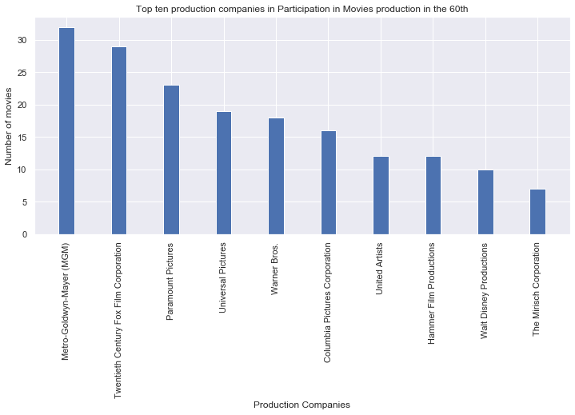

```
..................................................................................................................
The Top Ten Production companies in the 70th
dict_items([('Universal Pictures', 48), ('Paramount Pictures', 45), ('Warner Bros.', 45), ('Twentieth Century Fox Film Corporation', 26), ('United Artists', 23), ('Columbia Pictures Corporation', 22), ('Metro-Goldwyn-Mayer (MGM)', 18), ('American International Pictures (AIP)', 17), ('Columbia Pictur…
```

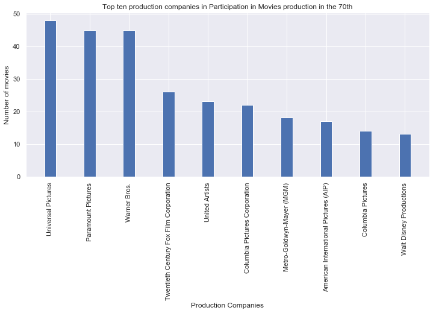

```
..................................................................................................................
The Top Ten Production companies in the 80th
dict_items([('Warner Bros.', 89), ('Paramount Pictures', 84), ('Universal Pictures', 80), ('TriStar Pictures', 56), ('Orion Pictures', 55), ('Twentieth Century Fox Film Corporation', 40), ('Metro-Goldwyn-Mayer (MGM)', 38), ('Columbia Pictures', 31), ('Touchstone Pictures', 28), ('Columbia Pictures C…
```

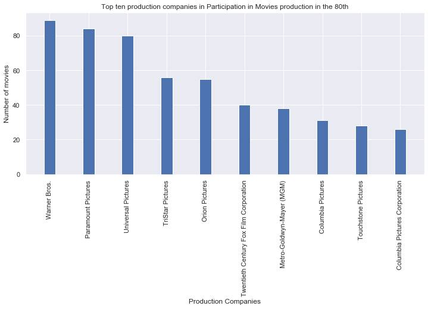

```
..................................................................................................................
The Top Ten Production companies in the 90th
dict_items([('Warner Bros.', 150), ('Universal Pictures', 133), ('Paramount Pictures', 118), ('New Line Cinema', 86), ('Columbia Pictures', 78), ('Miramax Films', 70), ('Touchstone Pictures', 69), ('Twentieth Century Fox Film Corporation', 69), ('TriStar Pictures', 66), ('Walt Disney Pictures', 59)]…
```

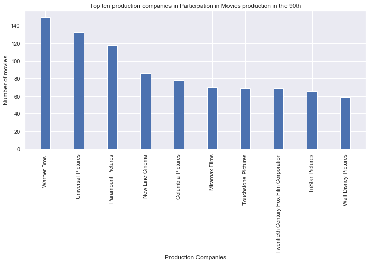

```
..................................................................................................................
The Top Ten Production companies in the 21century
dict_items([('Universal Pictures', 210), ('Warner Bros.', 193), ('Paramount Pictures', 149), ('Columbia Pictures', 139), ('Walt Disney Pictures', 117), ('New Line Cinema', 112), ('Twentieth Century Fox Film Corporation', 111), ('Relativity Media', 105), ('Metro-Goldwyn-Mayer (MGM)', 77), ('Village R…
```

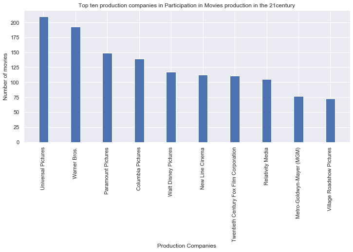

```
..................................................................................................................
```

```python
#looping on the groups that are produced from the group by function and each group we will do our processing
for group_name, df_group in df_YearsGrouped:
    dictionary = {}   #initialize a dictionary to add the production companies with their repetition

    for row_index, row in df_group.iterrows():   #iterate over the rows of each group
        productionCompanies = row['production_companies'].split('|')  #because there are several production comapnies participating in each movie , so we will split those companies by using split function
        for company in productionCompanies :  #adding a new company to the dictionary or if it is found then increase its value by one
            if company in dictionary :
                oldValue = dictionary[company]
                newValue=oldValue+1
                dictionary[company] = newValue
            else :
                dictionary[company]=1

    a=dict(sorted(dictionary.items(), key=lambda x: x[1], reverse=True)[:10]).items()  #sort the companies in the dictionary and get the highst 10 companies

    print ("The Top Ten Production companies in the {}".format(group_name))
    print (a)

    x, y = zip(*a) # unpack a list of pairs into two tuples
    plt.rcParams.update({'font.size': 8})    #we will specifiy the prop. of the Plot
    plt.figure(figsize=(12,5))
    plt.bar(x, y,width=0.3)
    plt.xticks(rotation='vertical')
    plt.xlabel("Production Companies")
    plt.ylabel("Number of movies")
    plt.title("Top ten production companies in Participation in Movies production in the {}".format(group_name))


    plt.show() # showing the plot
    print ("..................................................................................................................")
```

Plotting the Top 10 production company in each time period

As shown in the Charts :

- in the 60th : MGM came first with more than 30 movies , then Twenteith century Fox films with almost 30 movies , then Paramount pictures with about 23 movies .
- in the 70th : Universal pictures came first with nearly 50 movies (which was the fourth rank in the 60th , means an big increase in its production ) , then Paramount pictures and Warner bros each with 45 movies .
- in the 80th : Warner Bros came first with nearly 90 movies , then Paramount pictures with about 85 movies and then Universal pictures with about 80 movies ( Note they are the same top 3 as in the previous period ) .
- in the 90th : Warner Bros came first with nearly 150 movies ,then Universal pictures with about 135 movies , then Paramount pictures with nearly 120 movies ( Note they are the same top 3 as in the previous period ) .
- in the 21century : Universal pictures came first with more than 200 movies ,then Warner Bros with about 190 movies , then Paramount pictures with nearly 150 movies ( Note they are the same top 3 as in the previous period ) .
- ### Research Question 2 (What is the highst time period in production of movies)

Here we will investigate the number of movies produced by all production companies in a specific time intervals , as in the previous question .

```python
#count the number of movies in each group using count function
df_YearsGrouped.count().original_title
```

```
period_category
60th          372
70th          511
80th          986
90th         1638
21century    5159
Name: original_title, dtype: int64
```

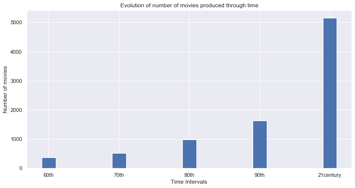

```python
x=['60th','70th','80th','90th','21century']
y=[372,511,986,1638,5159]

#plot a bar chart between the time interval and the number of movies
plt.figure(figsize=(12,6))
plt.bar(x, y,width=0.2)
plt.xlabel("Time Intervals")
plt.ylabel("Number of movies")
plt.title("Evolution of number of movies produced through time")
```

As shown in the bar chart :

- In the 60th and the 70th , about 500 movies were only produced by all production companies .
- Untill the 80th , the Total movies produced were about 1000 movies , while in the 90th the number increased to be less than 2000 .
- In the 21century , there was a huge breakthrough to the number , which reached above 5000 movies , which indicates flourish in this industry .
- ### Research Question 3 (Relation between Runtime and success of movies)

Here we are going to assume that the average vote result is an indication to the success of the movie . We are going to investigate if there is a relation ship between the average vote result and the run time of the movie .

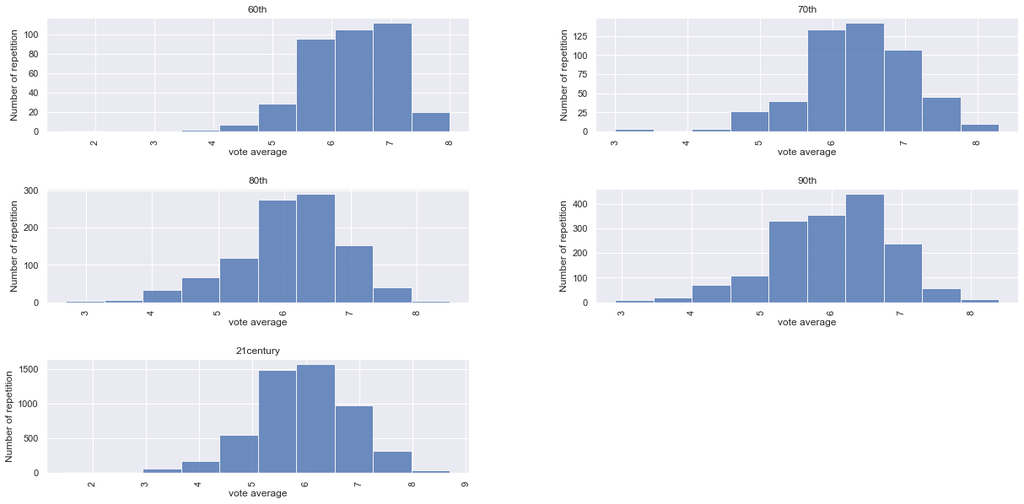

```python
#viewing the histogram of the average vote result in each group period
hist1 = df.vote_average.hist(by=df.period_category,alpha=0.8, figsize=(20, 10))

for x in hist1 :
    x[0].set_ylabel('Number of repetition')
    x[0].set_xlabel('vote average')
    x[1].set_ylabel('Number of repetition')
    x[1].set_xlabel('vote average')
```

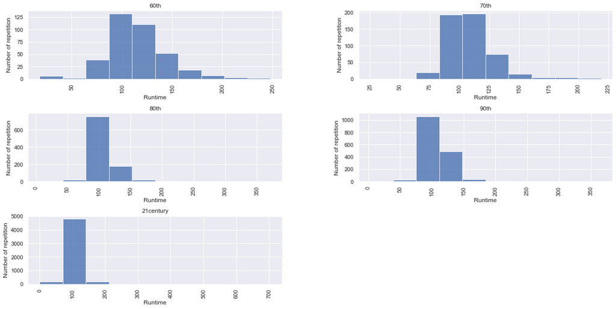

```python
##viewing the histogram of the run time in each group period
hist2 = df.runtime.hist(by=df.period_category,alpha=0.8, figsize=(20, 10))
for x in hist2 :
    x[0].set_ylabel('Number of repetition')
    x[0].set_xlabel('Runtime')
    x[1].set_ylabel('Number of repetition')
    x[1].set_xlabel('Runtime')
```

As shown in the histograms:

```python
y=df.vote_average
x=df.runtime
```

```
Correlation is : (0.20344431905582241, 1.2508987443070883e-81)
```

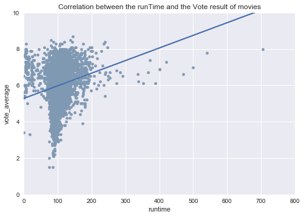

```python
import statsmodels.api as sm
import scipy as sc
#we will plot a relation between the run time vs The v=average vote result

#regression expression
model = sm.OLS(df.vote_average,sm.add_constant(df.runtime))
p=model.fit().params
Color = ny.array([.5, .6, .7])
#scatter plot data
ax=df.plot(x='runtime' , y='vote_average', kind ='scatter' ,title='Correlation between the runTime and the Vote result of movies',c= ny.atleast_2d(Color))


#plot regression line on the same axis
ax.plot(x,p.const + p.runtime* x)
ax.set_xlim([0,800])
ax.set_ylim([0,10])

print ("Correlation is :",sc.stats.pearsonr(x,y))
```

As shown in the scatter plot :

- It is shown that there is a very weak correlation between the run time of the movie and the average vote result .
- ### Research Question 4 (Relation between the Genre and the movies (average vote result & count of movies))

We will discuss if the Genre of the movie is affecting the average vote result of the movie in the same time intervals that we grouped the dataset into in the previous questions.

Since each movie can belong to several genres , we want to make a list of distinct genres , and then we can iterate over the rows to count the genres and calculate the average score .

Because the count of votes is not consistent over the movies , we want to calculate a weighted average vote result depending on the number of the votes , so we will assume a weighting function to calculate a weighted result , just to distinct the movies that have higher count of votes .

The Function is :

$$WA = CA * log (VC)$$

where :

$WA : Weighted Average$

$CA : Calculated Average$

$VC : Votes Count$

```
The  60th Group
```

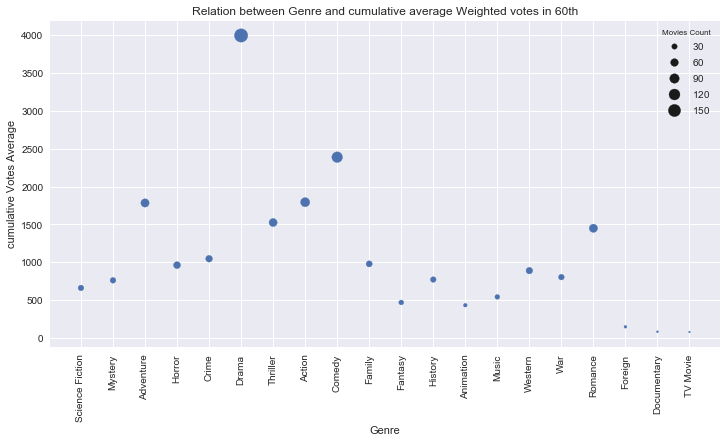

```
.........................................................................................................
The  70th Group
```

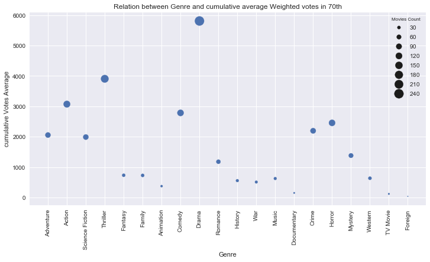

```
.........................................................................................................
The  80th Group
```

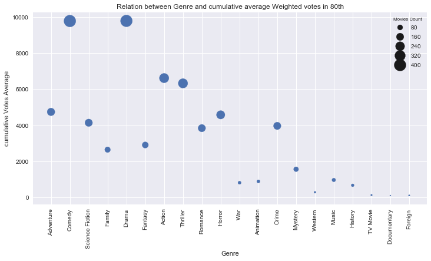

```
.........................................................................................................
The  90th Group
```

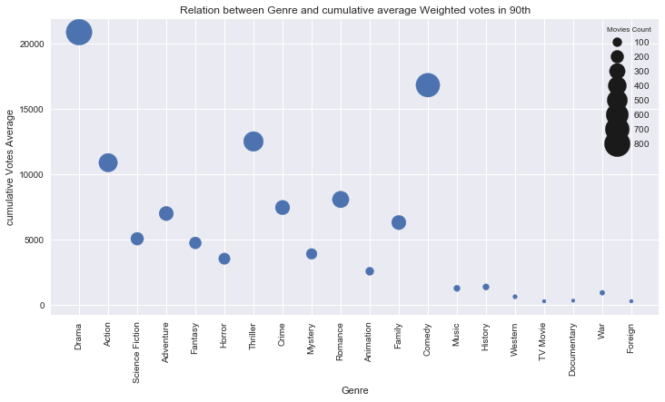

```
.........................................................................................................
The  21century Group
```

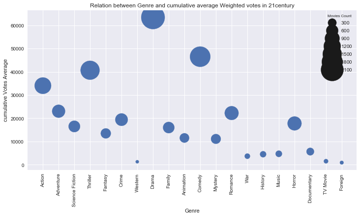

```
.........................................................................................................
```

```python
import math # import math to use thhe log function

for group_name, df_group in df_YearsGrouped : #iterate over each group in the time intervals as before
    listOfGenres =[] #list to add the distinct genre types
    GenresDict = {} #dictionary to addthe genre along with the value of repetition

    for row_index, row in df_group.iterrows() : #iterate over each row to get the genre types
        genres = row['genres'].split('|')  #use split function to split the genres
        for genre in genres :
            if genre in listOfGenres :
                #do nothing we want distinct values of genres in the list
                continue
            else :
                #add the genre to the list
                listOfGenres.append(genre)

    for genre in listOfGenres :  #iterate over the genres in the list and calculate their repetition
        movie_counter=0   #initialize a movies counter
        WA=0  #initilaize a weighted average variable

        for row_index, row in df_group.iterrows() :  #iterate over the rows again to calculate the number of movies along with the weighted average vote result
            if genre in row['genres'] :  #if the genre is in the row
                movie_counter=movie_counter+1   #increment the movies counter
                WA = WA + (row['vote_average'] * math.log(row['vote_count'])) #calculate the accumulative weighted average

        tupleOfValues=(WA,movie_counter)  #create a tuple to put the weighted average with the movie counter as a value in the dictionary
        GenresDict[genre]=tupleOfValues  # assign the tuple as a value in the dictionary

    x=list(GenresDict.keys())
    y=list(GenresDict.values())
    cumulativeVotesAverage, moviesCount = zip(*y)  #unpack the tuple of values

    print ("The  {}".format(group_name)+" Group")
    plt.style.use('seaborn')

    plt.figure(figsize=(12,6))
    plt.xlabel("Genre")
    plt.xticks(rotation='vertical')
    plt.ylabel("cumulative Votes Average")
    plt.title("Relation between Genre and cumulative average Weighted votes in {}".format(group_name))


    sc=plt.scatter(x,cumulativeVotesAverage,s=moviesCount)  #we will print a bubble chart
    plt.legend(*sc.legend_elements("sizes",num=6),title="Movies Count")  #The size of bubble indicates the count of movies in this genre
    plt.show()

    print (".........................................................................................................")
```

As shown in the bubble plot :

- in the 60th : It is obvious that the Drama Genre is the most successfull genre according to the Votes of People , followed by the Comedy Genre . These two genres are also the first and second ranks in the count of movies among other genres .
- in the 70th : Drama Genre is still on the top in the count of movies and also people's opinions , followes by the Thriller genre and then the Comedy and action genre is very near to each other .
- in the 80th : It seems that there were a huge number of Comedy movies produced in that period , so the comedy genre has jumped the first rank with drama genre which keeps the first position from the 60th , then the action and Thriller genres are competing in the second and third place .
- in the 90th : The drama genre is on top as usual and the comedy genre in the second place , the action and thriller are still competing very close to each other , and there are some other genres that are evolving like crime and romantic genres
- in the 21century : The drama genre is also on Top ,followed by comedy , thriller and action , and then followes by Romance and adventure genres .
- ### Research Question 5 (Who is the most successfull director with regard to number of movies and votes average)

We will group our dataset by the same previous time interval and by the director.

```
60th
```

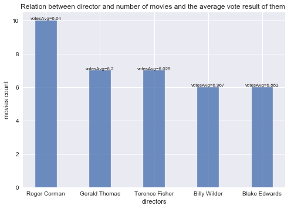

```
70th
```

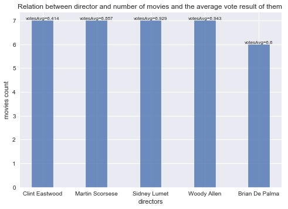

```
80th
```

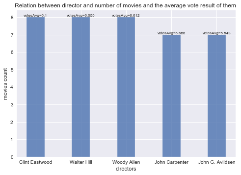

```
90th
```

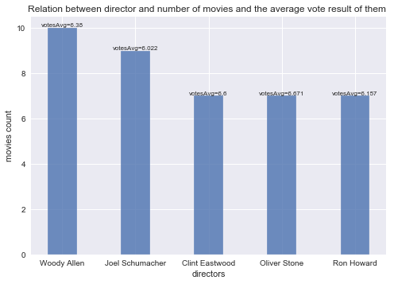

```
21century
```

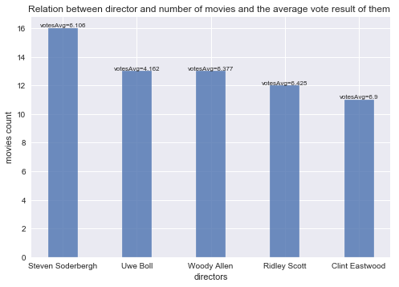

```python
for group_name, df_group in df_YearsGrouped :   #here we will iterate over the groups that are grouped by the period and regroup them with the director also
    print (group_name)

    #grouping by the director , and then getting the count of movies and the sum of the average votes , and selecting the largest 5 directors in movies count
    df1 = df_group.groupby('director').agg({'original_title':'count', 'vote_average': 'sum'}).reset_index().nlargest(5,columns='original_title')

    df2 = pa.DataFrame(data=df1)  #forming a new dataframe of the previous output

    df2.rename(columns={'original_title':'countOfMovies'},inplace=True)  #rename the column 'original_title' to 'countOfMovies' since it is aggregated on the count

    df2['new_VoteAvergare']=df2['vote_average']/df2['countOfMovies']  #we make a new column in the dataframe which is the result of dividing the sum of the Average vote result with the movies count

    x=df2['director']
    y=df2['countOfMovies']
    z=df2['new_VoteAvergare']



    opacity = 0.8
    bar_width = 0.4

    plt.xlabel('directors')
    plt.ylabel('movies count')
    plt.title("Relation between director and number of movies and the average vote result of them ")


    chart = plt.bar(x,y, bar_width, align='center', alpha=opacity, color='b')


    # Add average vote results above the bar graph for indication
    for index,rect in enumerate(chart) :
        length = rect.get_height()
        plt.text(x = index ,y = length ,s='votesAvg='+str(round(z.iloc[index],3)) ,ha='center', va='bottom')

    plt.show()
```

As shown in the bar chart :

- in the 60th : Roger Corman was the highest director in the number of movies , however he was nearly the worst in the votes result , while Billy Wilder and Blake Edwards have an opposite case ( low number of movies and high vote result ) .
- in the 70th : There are 4 directors who share the same number of movies and also their vote result is very near , but Woody Allen who had the highest vote result .
- in the 80th : It seems that Woody Allen is still on the top in the count of movies , also his vote result is very good , but John Carpenter exceeds him in the vote result .
- in the 90th : As in the previous period , Woody Allen is still on the top in the count of movies , while Oliver Stone and Clint Eastwood are the most successfull in the votes result .
- in the 21century : Steven Soderbergh has the highest count of movies but with a relativly low vote result , whilethe contrast happened with Clint Easwtood which had the lowest count of movies and highest vote result .
- ### Conclusions

Here in this section , we will summarize our analysis and conclude our results that are based upon our analysis in the previous sections

- #### Overview of the dataset
- This dataset is called TDMB dataset , it has data related to movies and some of their attributes from 1960 untill 2015 .
- The dataset has initilally 10866 rows and 21 columns .
- The information in this dataset is related to the movie along with its release date , production companies , cast , director votes result , revenue , budget ...etc.
- #### Summary for the data cleaning process
- We cleaned our data by removing duplicate rows if any .
- We deleted the rows that contain null values
- We dropped the columns that we we don't need in our analysis like the id , homepage , tagline and others
- we dropped columns like budget and revenue because nearly more than 60 % of the total data in them were zero values ( means they are unknown ) so it is some sort of biased data , and Our approach was to measure the success of the movie by measuring its votes count and votes average result .
- #### Limitations of the dataset
- Some columns like Genres and cast have multiple values in each cell .
- Some fields have some unrecognized characters in its values .
- Columns as budget and revenue have biased values in more than 60% of their data ( either zero or very small unreasonable value like 2 or 3 ) , so it was better to collect this data properly to have better analysis in this part .
- It would had been better if we had the values in the Genres column a single value i.e. to put the main genre of the movie only in the genres column , so that to have clear insights about the trends of the genres in each time interval and what genres does people like the most .
- #### Summary of analysis
- In our Approach we mainly divide the dataset into 5 different intervals according to the release year , either in the 60th or 70th or 80th or 90th or the 21century , we aimed to find changes among number of movies , genres of movies and production companies all over these passing years .
- You can find detailed analysis below the graphs of each question .
- #### Question 1
- Details are Just below the graphs in question 1.

General conclusion for question 1 :

- The top 3 companies in participating in movies production haven't changed since the 70th but they only exchange rankings .
- There are also some companies which are always present in the Top 10 list like Twenteith century Fox films and coloumbia pictures .
- #### Question 2
- Details are Just below the graphs in question 2.
- There is a big evolution generally in the movies production industry from the 60th till now .
- If the increase in movies production keeps its rate , the next 10 years will have not less than 8000 movies produced .
- #### Question 3
- Details are Just below the graphs in question 3.

As shown in the Scatter plot :

- There is no strong correlation between the run time of the movies and its vote result .The correlation is computed to be around 0.2 , which means that the run time doesnt have a significant impact on the opinions of users
- #### Question 4
- Details are Just below the graphs in question 4.

General conclusion :

- It is not mandatory that the director makes a higher number of movies to grab people's attention , sometimes making a lower number of movies makes the director focus on his job a lot and thus leading to higher votes result .

## *References*

The references to the work done in this dataset is:

- Udacity Lessons
- www.geeksforgeeks.org
- www.stackoverflow.com
- Pandas official documentation
- Matplotlib official documentation